# STAT 413/613 Homework: Tidy Text

Sihyuan Han

2021-04-27

# 1 Sentiment Analysis

1. Download the following two works from the early 20<sup>th</sup> century from Project Gutenberg:
- Upton Sinclair: “*The Jungle*” (1906)
- W.E.B. Du Bois: “*The Quest of the Silver Fleece*” (1911)

```r
library(tidyverse)
library(tidytext)
library(gutenbergr)

gutenberg_works() %>%
  filter(str_detect(title, "The Jungle")) # get id 140
```

```
## # A tibble: 5 x 8
##   gutenberg_id title   author gutenberg_autho… language gutenberg_booksh… rights
##          <int> <chr>   <chr>             <int> <chr>    <chr>             <chr>
## 1          140 "The J… Sincl…               88 en       Bestsellers, Ame… Publi…
## 2          236 "The J… Kipli…              132 en       Movie Books/Scou… Publi…
## 3        14087 "The J… Casse…             5361 en       <NA>              Publi…
## 4        16805 "The J… Ellis…             2569 en       Children's Ficti… Publi…
## 5        20693 "The J… Farro…             7640 en       Children's Pictu… Publi…
## # … with 1 more variable: has_text <lgl>
```

```r
gutenberg_works() %>%
  filter(str_detect(title, "The Quest of the Silver Fleece")) # get id 15265
```

```
## # A tibble: 1 x 8
##   gutenberg_id title  author   gutenberg_autho… language gutenberg_books… rights
##          <int> <chr>  <chr>               <int> <chr>    <chr>            <chr>
## 1        15265 The Q… Du Bois…              226 en       African America… Publi…
## # … with 1 more variable: has_text <lgl>
```

```r
t_jungle <- gutenberg_download(140)
```

```
## Determining mirror for Project Gutenberg from http://www.gutenberg.org/robot/harvest
```

```
## Using mirror http://aleph.gutenberg.org
```

```r
t_questSF <- gutenberg_download(15265)
```

2. Write a function `to take an argument of a downloaded book tibble and return it in tidy text format.
- The function must add line and chapter numbers as variables
- The function must unnest tokens at the word level
- The function must remove any Project Gutenberg formatting so only the words remain
- The function must remove any stop_words and filter out any `NA`s
- The function must remove any front matter (words before Chapter 1)
- The function can consider the unique nature of the front matter but cannot consider exactly how many chapters are in each book based on looking at the data i.e., no math based on knowing the number of chapters.

```r
data("stop_words")

tidybook <- function(x){
  x %>%
    mutate(linenumber = row_number(),    # add line and chapter numbers as variables
           text = str_replace(text, "_Contents_", "Contents"),
           text = str_replace(text, "_Note_", "Note"),
           chapter = cumsum(str_detect(text,
                                       regex("(^chapter [ivxlc])|(^_[a-z]+_$)",
                                             ignore_case = TRUE)))) %>%
    unnest_tokens(word, text) %>%        # unnest tokens at the word level
    mutate(word = str_extract(word, "[a-z']+")) %>% # only the words remain
    anti_join(stop_words, by = "word") %>%         # filter out stop_words and any `NA`s
    drop_na() %>%
    filter(chapter != 0) ->                        # remove any front matter
    y
  y
}
```

3. Use the function from step 2
- Tidy each book and then add `book` and `author` as variables and save each tibble to a new variable. How many rows are in each book?

```r
tidybook(t_jungle) %>%
  mutate(book = "The Jungle",
         author = "Sinclair, Upton") ->
  t_jungle_tidy
nrow(t_jungle_tidy)
```

```
## [1] 47828
```

```r
tidybook(t_questSF) %>%
  mutate(book = "The Quest of the Silver Fleece: A Novel",
         author = "Du Bois, W. E. B. (William Edward Burghardt)") ->
  t_questSF_tidy
nrow(t_questSF_tidy)
```

```
## [1] 41606
```

4. Use a dplyr function to combine the two tibbles into a new tibble.
- It should have 89,434 rows with 6 variables

```r
full_join(t_jungle_tidy, t_questSF_tidy) ->
  twobooks_tidy
nrow(twobooks_tidy)
```

```
## [1] 89434
```

5. Measure the net sentiment using bing for each block of 50 lines
- Plot the sentiment for each book in an appropriate faceted plot - either line or column.
- Be sure to remove the legend.
- Save the plot to a variable
- Interpret the plots for each book and compare them.

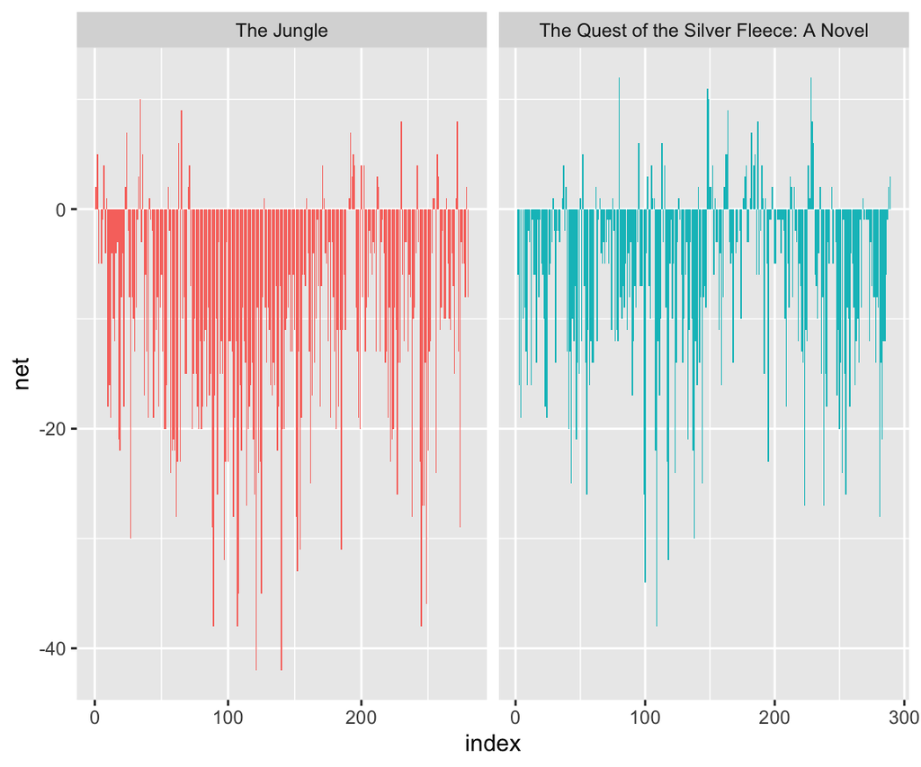

```r
twobooks_tidy %>%
  inner_join(get_sentiments("bing"), by = "word") %>%
  count(book, index = linenumber %/% 50, sentiment, book, sort = TRUE) %>%
  pivot_wider(names_from = sentiment, values_from = n, values_fill = list(n = 0)) %>%
  mutate(net = positive - negative) %>%
  ggplot(aes(index, net, fill = book)) +
  geom_col(show.legend = FALSE) +
  facet_wrap(~book, ncol = 2, scales = "free_x") ->
  books_bing_plot
books_bing_plot
```

```r
# Interpretation: "The Jungle" seems to be more negative in the middle of the story while "The Quest of the Silver Fleece" has more negative plot towards the end
```

6. Measure the total for each nrc sentiment in each block of 500 lines and then,
- Filter out the “positive” and “negative” and save to a new variable. You should have 464 observations.
- Plot the count of the sentiments for each block in each book in an appropriate faceted plot with the books in two columns and the sentiments in 8 rows.
- Be sure to remove the legend.
- Interpret the plots for each book and then compare them.
- Why did the values drop off so suddenly at the end?

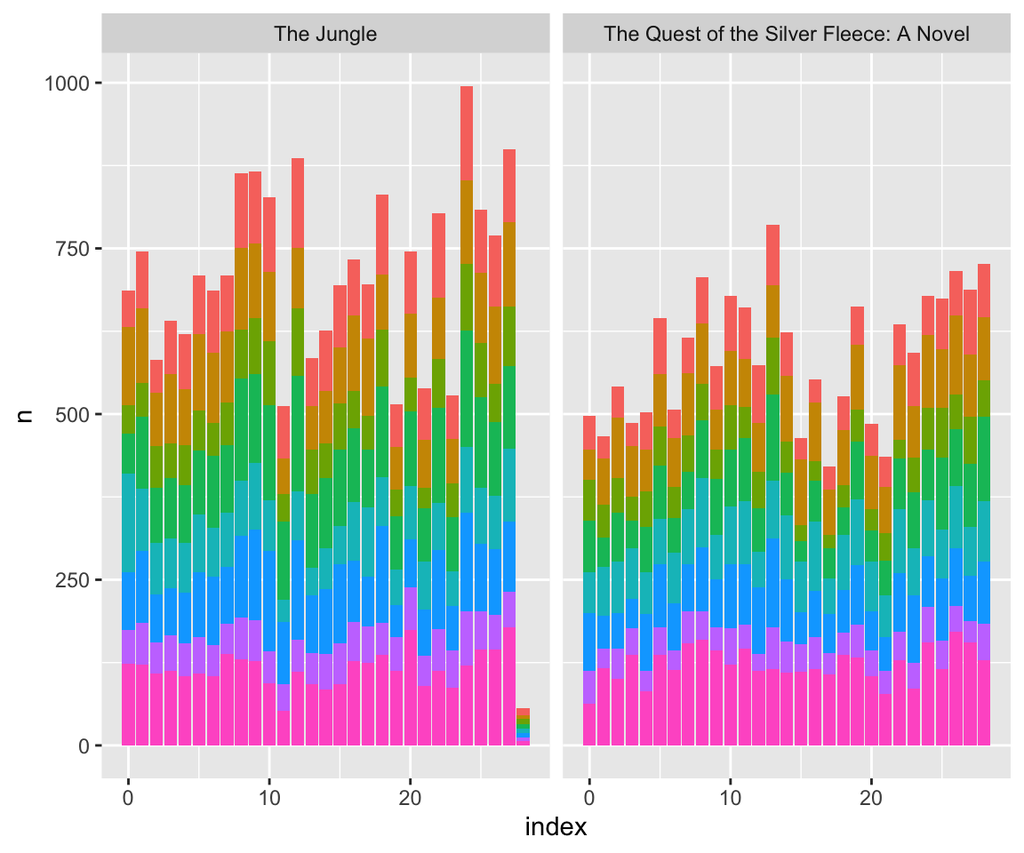

```r
twobooks_tidy %>%
  inner_join(get_sentiments("nrc"), by = "word") %>%
  count(book, index = linenumber %/% 500, sentiment, book, sort = TRUE) %>%
  filter(!(sentiment == "negative" | sentiment == "positive")) ->
  nrc_no_posneg # 464

nrc_no_posneg %>%
  ggplot(aes(x = index, y = n, fill = sentiment)) +
  geom_col(show.legend = F) +
  facet_grid(~book)
```

```r
# Interpretation: It seems like both books have similar sentiment structures through out each block, the suddenly drop off could be the short ending in "The Jungle"
```

7. Using bing, create a new data frame with the counts of the positive and negative sentiment words for each book.
- Show the “top 20” most frequent words across both books along with their book, sentiment, and count, in descending order by count.
- What are the positive words in the list of “top 20”?

```r
# new df
twobooks_tidy %>%
  inner_join(get_sentiments("bing"), by = "word") %>%
  count(book, word, sentiment, sort = TRUE) %>%
  ungroup() ->
  books_bing_count
# "top 20" most frequent words across both books
books_bing_count %>%
  arrange(desc(n)) %>%
  head(20)
```

```
## # A tibble: 20 x 4
##    book                                    word    sentiment     n
##    <chr>                                   <chr>   <chr>     <int>
##  1 The Quest of the Silver Fleece: A Novel miss    negative    467
##  2 The Quest of the Silver Fleece: A Novel slowly  negative    124
##  3 The Quest of the Silver Fleece: A Novel dark    negative     96
##  4 The Jungle                              poor    negative     80
##  5 The Jungle                              cold    negative     79
##  6 The Jungle                              hard    negative     61
##  7 The Jungle                              lost    negative     61
##  8 The Jungle                              wild    negative     55
##  9 The Quest of the Silver Fleece: A Novel love    positive     54
## 10 The Jungle                              fell    negative     51
## 11 The Quest of the Silver Fleece: A Novel fell    negative     50
## 12 The Quest of the Silver Fleece: A Novel mighty  positive     48
## 13 The Jungle                              death   negative     47
## 14 The Jungle                              free    positive     44
## 15 The Jungle                              killing negative     43
## 16 The Quest of the Silver Fleece: A Novel silent  positive     43
## 17 The Jungle                              cry     negative     41
## 18 The Jungle                              agony   negative     40
## 19 The Quest of the Silver Fleece: A Novel hard    negative     40
## 20 The Jungle                              dead    negative     39
```

```r
# positive words in the list of "top 20"?
books_bing_count %>%
  arrange(desc(n)) %>%
  head(20) %>%
  filter(sentiment == "positive")
```

```
## # A tibble: 4 x 4
##   book                                    word   sentiment     n
##   <chr>                                   <chr>  <chr>     <int>
## 1 The Quest of the Silver Fleece: A Novel love   positive     54
## 2 The Quest of the Silver Fleece: A Novel mighty positive     48
## 3 The Jungle                              free   positive     44
## 4 The Quest of the Silver Fleece: A Novel silent positive     43
```

8. Plot the top ten for each positive and negative sentiment faceting by book.
- Ensure each facet has the words in the proper order for that book.
- Identify any that may be inappropriate for the context of the book and should be excluded from the sentiment analysis.

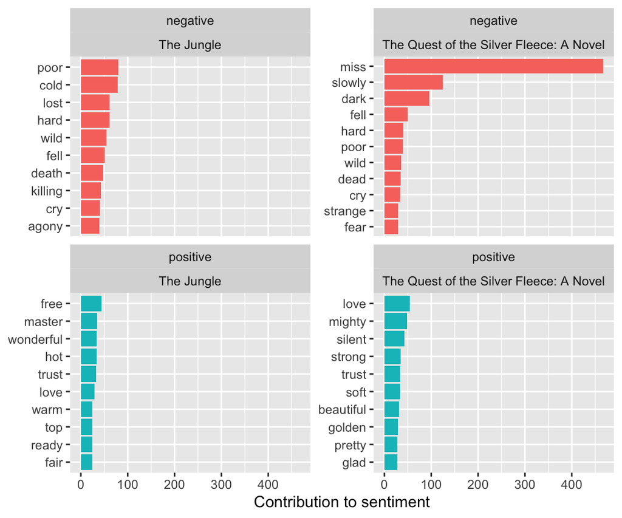

```r
books_bing_count %>%
  group_by(book, sentiment) %>%
  slice_max(order_by = n, n = 10) %>%
  mutate(word = reorder_within(word, n, book)) %>%
  ungroup() %>%
  ggplot(aes(word, n, fill = sentiment)) +
  geom_col(show.legend = FALSE) +
  facet_wrap(sentiment ~book, scales = "free_y") +
  scale_x_reordered() +
  labs(y = "Contribution to sentiment",
       x = NULL) +
  coord_flip()
```

```r
# "miss" may be inappropriate for the context of the book
```

9. Remove the inappropriate word(s) from the analysis.
- Replot the top 10 for each sentiment per book from step 8.
- Interpret the plots

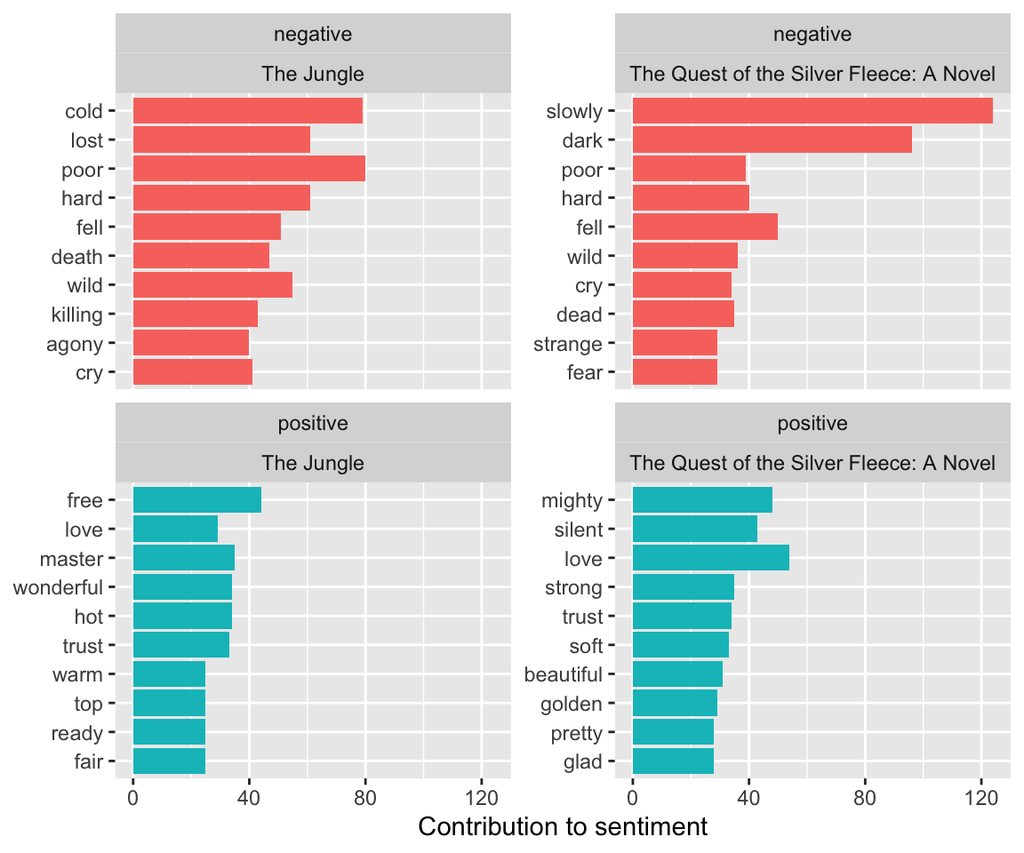

```r
# filter out miss
get_sentiments("bing") %>%
  filter(word != "miss") ->
bing_no_miss

# no miss df
twobooks_tidy %>%
  inner_join(bing_no_miss, by = "word") %>%
  group_by(book, word, sentiment) %>%
  count() ->
  books_bing_nomiss

books_bing_nomiss %>%
  group_by(book, sentiment) %>%
  slice_max(order_by = n, n = 10) %>%
  ungroup() %>%
  mutate(word = reorder(word, n)) %>%
  ggplot(aes(x = word, y = n, fill = sentiment)) +
  geom_col(show.legend = FALSE) +
  facet_wrap(sentiment ~book, scales = "free_y") +
  labs(y = "Contribution to sentiment",
       x = NULL) +
  coord_flip()
```

```r
# Interpretation: "miss" may not be the negative word in the novel, it may refers to young lady, the new plot shows that "slowly" is the most common negative word in "The Quest" with understandable counts, since "miss" is over 400. Based on the new plot we can also see that negative sentiments are more than positive sentiments for both books
```

10. Rerun the analysis from step 5 and recreate the plot with the title “Custom Bing”.
- Show both the original step 5 plot with the new plot in the same output graphic, one on top of the other.
- Interpret the plots

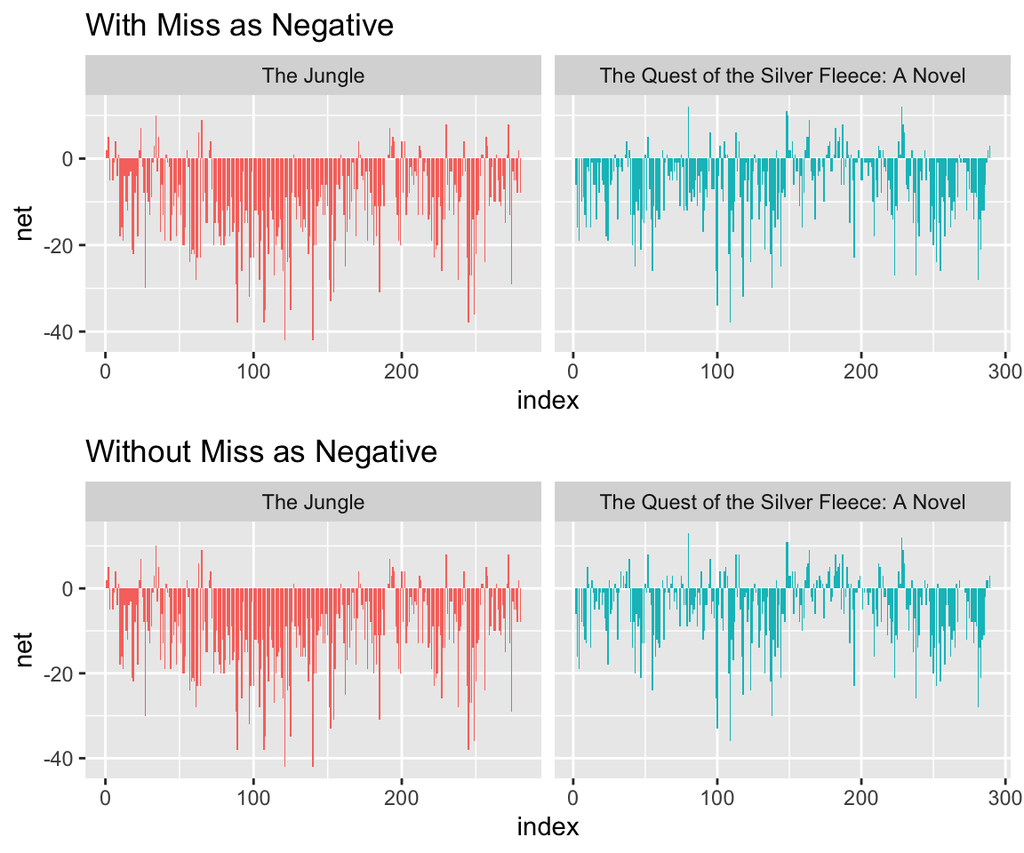

```r
# from step5
twobooks_tidy %>%
  inner_join(get_sentiments("bing"), by = "word") %>%
  count(book, index = linenumber %/% 50, sentiment, book, sort = TRUE) %>%
  pivot_wider(names_from = sentiment, values_from = n, values_fill = list(n = 0)) %>%
  mutate(net = positive - negative) %>%
  ggplot(aes(index, net, fill = book)) +
  ggtitle("With Miss as Negative" ) +
  geom_col(show.legend = FALSE) +
  facet_wrap(~book, ncol = 2, scales = "free_x") ->
  p1

twobooks_tidy %>%
  inner_join(bing_no_miss, by = "word") %>%
  count(book, index = linenumber %/% 50, sentiment, book, sort = TRUE) %>%
  pivot_wider(names_from = sentiment, values_from = n, values_fill = list(n = 0)) %>%
  mutate(net = positive - negative) %>%
  ggplot(aes(index, net, fill = book)) +
  ggtitle("Without Miss as Negative" ) +
  geom_col(show.legend = FALSE) +
  facet_wrap(~book, ncol = 2, scales = "free_x") ->
  p2

library(gridExtra)
grid.arrange(p1, p2, nrow=2)
```

```r
# Interpretation: "The Quest" is slightly not that negative after filtering out "miss"
```